# Project 2: Data Mining, Classification, Prediction

SDS322E

# Mining, Classification, Prediction

## Sarah Zhang (sz6753)

### Introduction

The dataset that I chose is the Mroz dataset which I acquired from https://vincentarelbundock.github.io/Rdatasets/datasets.html. This dataset shows data about the U.S. Women’s Labor-Force Participation which interested me because I’m a woman who is planning on participating in the labor-force and I’m curious to see how/if some factors affect women’s labor-force participation. This dataset has 753 observations and 8 variables. The variables are lfp (binary), k5 (numeric), k618 (numeric), age (numeric), wc (binary), hc (binary), lwg (numeric), and inc (numeric). The lfp variable represents a boolean value of whether the woman participates in the labor-force or not. The k5 variable represents the number of children that are 5 years old or younger that the woman has. The k618 variable represents the number of children that are 6-17 years old that the woman has. The age variable represents the age of the woman. The wc variable represents if the woman attended college or not. The hc variable represents if the woman’s husband attended college or not. The lwg represents the log expected wage rate of the woman. For women in the labor force, it represents the actual wage rate and for women not in the labor force it represents an imputed value based on the regression of lwg on the other variables. The inc variable represents the income of the woman’s family exclusive of wife’s income. None of the variables are missing data so there are also 753 observations for each of the variables.

```r
library(tidyverse)
mroz <- read_csv("Mroz.csv")
mroz <- mroz %>% select(-X1)
head(mroz)
```

```
## # A tibble: 6 x 8
##   lfp      k5  k618   age wc    hc       lwg   inc
##   <lgl> <dbl> <dbl> <dbl> <lgl> <lgl>  <dbl> <dbl>
## 1 TRUE      1     0    32 FALSE FALSE 1.21   10.9
## 2 TRUE      0     2    30 FALSE FALSE 0.329  19.5
## 3 TRUE      1     3    35 FALSE FALSE 1.51   12.0
## 4 TRUE      0     3    34 FALSE FALSE 0.0921  6.80
## 5 TRUE      1     2    31 TRUE  FALSE 1.52   20.1
## 6 TRUE      0     0    54 FALSE FALSE 1.56    9.86
```

### Cluster Analysis

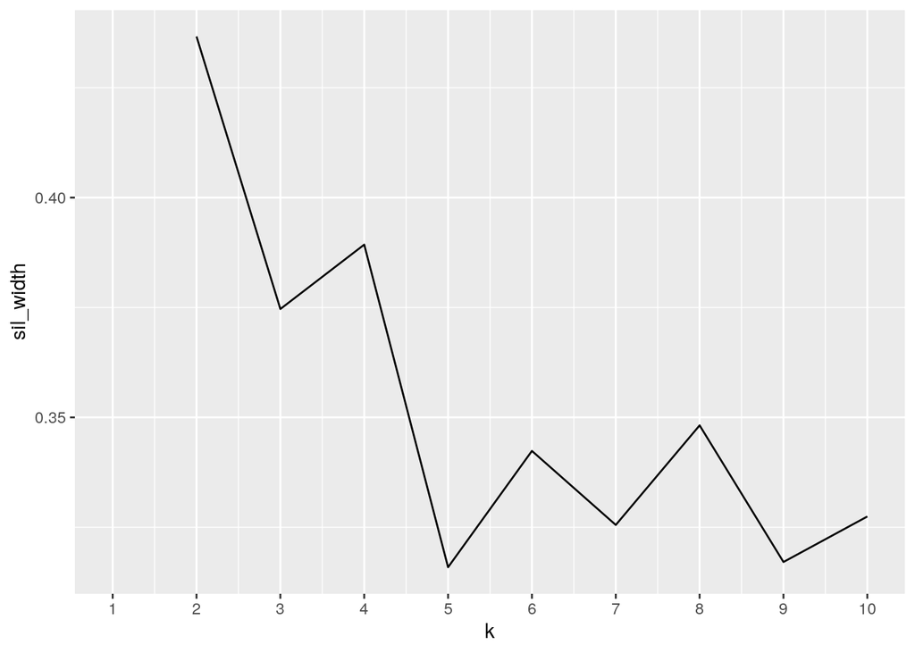

```r
library(cluster)
library(GGally)
sil_width <- vector()

mroz_numeric <- mroz %>% select(-wc) %>% select(-hc) %>% select(-lfp)
for (i in 2:10) {
    kms <- kmeans(mroz_numeric, centers = i)
    sil <- silhouette(kms$cluster, dist(mroz_numeric))
    sil_width[i] <- mean(sil[, 3])
}
ggplot() + geom_line(aes(x = 1:10, y = sil_width)) + scale_x_continuous(name = "k",
    breaks = 1:10)
```

```r
pam1 <- mroz_numeric %>% pam(k = 2)
pam1
```

```
## Medoids:
##       ID k5 k618 age       lwg    inc
## [1,]  36  0    1  42 0.9016919 14.197
## [2,] 735  0    2  43 1.0814669 28.069
## Clustering vector:
##   [1] 1 1 1 1 1 1 1 1 1 1 2 1 1 1 2 1 1 1 1 1 2 1 1 1 1 2 1 1 1 1 1 1 1 1 1 1 1
##  [38] 1 1 1 1 2 2 1 1 1 2 1 1 1 2 1 1 1 1 1 1 1 1 1 2 1 1 1 1 1 1 1 2 1 1 2 1 1
##  [75] 1 1 1 1 1 2 1 1 1 2 1 2 1 1 2 1 1 1 2 2 1 1 2 2 1 2
##  [ reached getOption("max.print") -- omitted 653 entries ]
## Objective function:
##    build     swap
## 9.982966 9.645225
##
## Available components:
##  [1] "medoids"    "id.med"     "clustering" "objective"  "isolation"
##  [6] "clusinfo"   "silinfo"    "diss"       "call"       "data"
```

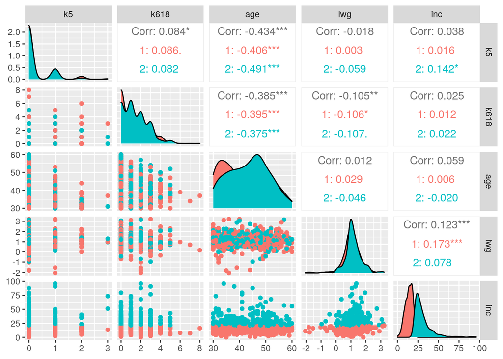

```r
mroz_numeric %>% mutate(cluster = as.factor(pam1$clustering)) %>%
    ggpairs(columns = 1:5, aes(color = cluster))
```

```r
pam1$silinfo$avg.width
```

```
## [1] 0.339421
```

```r
pam1$silinfo$clus.avg.widths
```

```
## [1] 0.4238756 0.1892102
```

[figure not shown]

```r
plot(pam1, which = 2)
```

```r
pam1$silinfo$avg.width
```

```
## [1] 0.339421
```

```r
pam1$silinfo$clus.avg.widths
```

```
## [1] 0.4238756 0.1892102
```